# Shoulder Range of Motion Smartform Use

Cameron Stahl

March 06, 2026

# Basics of this Data

## Rows Analyzed

This data includes documentation from 503 clinicians practicing in 71 clinics. Data is from a recorded date of 2025-10-13 through 2026-02-23, and covers all of the shoulder range of motion options listed below.

| Row_Name | Row_ID |
| --- | --- |
| Right Shoulder ADduction Range of Motion Within Normal Limits | 1570063879 |
| Right Shoulder ADduction Range of Motion Within Functional Limits | 1570063881 |
| Right Shoulder ADduction Pain with Range of Motion | 1570063882 |
| Right Shoulder ADduction Active Range of Motion | 1570063883 |
| Right Shoulder Horizontal ADduction Range of Motion Within Normal Limits | 1570063888 |
| Right Shoulder Horizontal ADduction Range of Motion Within Functional Limits | 1570063889 |
| Right Shoulder ADduction Passive Range of Motion | 1570063960 |
| Left Shoulder ADduction Active Range of Motion | 1570063965 |
| Left Shoulder ADduction Passive Range of Motion | 1570063970 |
| Right Shoulder Horizontal ADduction Pain with Range of Motion | 1570063980 |
| Right Shoulder Horizontal ADduction Active Range of Motion | 1570063985 |
| Left Shoulder ADduction Range of Motion Within Normal Limits | 1570630434 |
| Left Shoulder Flexion Active Range of Motion | 1570630599 |
| Left Shoulder Flexion Passive Range of Motion | 1570630600 |
| Left Shoulder Flexion Pain with Range of Motion | 1570630601 |
| Left Shoulder Flexion Range of Motion Within Functional Limits | 1570630604 |
| Left Shoulder Flexion Range of Motion Within Normal Limits | 1570630605 |
| Right Shoulder Flexion Active Range of Motion | 1570630606 |
| Right Shoulder Flexion Passive Range of Motion | 1570630607 |
| Right Shoulder Flexion Pain with Range of Motion | 1570630608 |
| Right Shoulder Flexion Range of Motion Within Functional Limits | 1570630611 |
| Right Shoulder Flexion Range of Motion Within Normal Limits | 1570630612 |
| Left Shoulder Scaption Active Range of Motion | 1570630613 |
| Left Shoulder Scaption Passive Range of Motion | 1570630614 |
| Left Shoulder Scaption Pain with Range of Motion | 1570630615 |
| Left Shoulder Scaption Range of Motion Within Functional Limits | 1570630618 |
| Left Shoulder Scaption Range of Motion Within Normal Limits | 1570630619 |
| Right Shoulder Scaption Active Range of Motion | 1570630620 |
| Right Shoulder Scaption Passive Range of Motion | 1570630621 |
| Right Shoulder Scaption Pain with Range of Motion | 1570630622 |

[output cut: 98 more lines]

## Higher Volume Clinics

Departments with more than 5 clinicians in this data are listed below (all clinics are included in the data, even if they only have one Therapist).

| Department | Clinician Count |
| --- | --- |
| INVERNESS PT/OT 100 OP | 46 |
| AMC PT OP | 26 |
| PPMP PT OP | 25 |
| EVMC PT OP | 24 |
| INTQST PT OP | 23 |
| INVERNESS PT/OT 130 OP | 19 |
| PROSPCT ADULT REHAB OP | 19 |
| GVMC PT OP | 18 |
| YVMC PT | 18 |
| CO CTR PT OT SPORTS OP | 15 |
| BOULDR PT OP | 15 |
| LPMC PT/OT OP | 15 |
| LNTREE REHAB THERAPY | 14 |
| CNTRAL PK REHAB OP | 14 |
| PPRH PT OP | 12 |
| WOODMN ADULT REHAB OP | 12 |
| GRMC PT OP | 12 |
| CCH PT OP | 11 |
| NORTHFLD PT OP | 11 |
| CC OCR FTC PT OP | 11 |
| HARMONY REHAB OP | 9 |
| AMC OT OP | 9 |
| CC OCR LVLD PT OP | 8 |
| MCC PT OP | 8 |
| CASTL RK PT OP | 8 |
| CC OCR LONGMT PT OP | 8 |
| SRMC PT | 8 |
| HARMONY ONC REHAB OP | 8 |
| RWPS PT OP | 7 |
| MCR ADULT REHAB OP | 7 |
| CC GNVH CB PT OP | 6 |
| PMC YMCA PT OP | 6 |

## Clinics and Locations

| Location | Department |
| --- | --- |
| CC CCH HOSPITAL [64601] | CCH PT OP |
| CC CCH HOSPITAL [64601] | CCH OT OP |
| CC CCH HOSPITAL [64601] | CC HULETT PT OP |
| CC CCH HOSPITAL [64601] | CC WRIGHT PT OP |
| CC EPH HOSPITAL [44901] | EPH PT OP |
| CC EPH HOSPITAL [44901] | EPH OT OP |
| CC GNVH OUTPATIENT SERVICES REV [55712] | CC GNVH CB PT OP |
| CC GNVH OUTPATIENT SERVICES REV [55712] | CC GNVH SPN PT OP |
| CC GNVH OUTPATIENT SERVICES REV [55712] | GNVH PT OP |
| CC GNVH OUTPATIENT SERVICES REV [55712] | GNVH SCC PT OP |
| CC GNVH OUTPATIENT SERVICES REV [55712] | GNVH SCC OT OP |
| CC GNVH OUTPATIENT SERVICES REV [55712] | GNVH OT OP |
| CC GNVH OUTPATIENT SERVICES REV [55712] | CC GNVH SPN OT OP |
| CC GNVH OUTPATIENT SERVICES REV [55712] | CC GNVH CB OT OP |
| CC OCR NORTH PC REV [61531] | CC OCR LVLD PT OP |
| CC OCR NORTH PC REV [61531] | CC OCR FTC PT OP |
| CC OCR NORTH PC REV [61531] | CC OCR FTC OT OP |
| CC OCR NORTH PC REV [61531] | CC OCR GREELEY PT OP |
| CC OCR NORTH PC REV [61531] | CC OCR LVLD OT OP |
| CC OCR SOUTH PC REV [61532] | CC OCR LONGMT PT OP |
| CC OCR SOUTH PC REV [61532] | CC OCR LAFYT PT OP |
| CC OCR SOUTH PC REV [61532] | CC OCR LAFYT OT OP |
| CC RW HOSPITAL [47001] | RWPS PT OP |
| CC RW HOSPITAL [47001] | RWPS OT OP |
| CC SRMC HOSPITAL [45101] | SRMC PT |
| CC SRMC HOSPITAL [45101] | SRMC OT |
| MCR OUTPATIENT SERVICES [10603] | MCR ADULT REHAB OP |
| MHC OUTPATIENT SERVICES [10806] | GVMC PT OP |
| MHC OUTPATIENT SERVICES [10806] | INTQST PT OP |
| MHC OUTPATIENT SERVICES [10806] | EVMC PT OP |
| MHC OUTPATIENT SERVICES [10806] | WOODMN ADULT REHAB OP |
| MHC OUTPATIENT SERVICES [10806] | GVMC OT OP |
| MHC OUTPATIENT SERVICES [10806] | EVMC OT OP |
| MHC OUTPATIENT SERVICES [10806] | INTQST OT OP |
| MHC PPMP [10802] | PPMP PT OP |
| MHC PPMP [10802] | PPMP OT OP |
| PMC HOSPITAL [10751] | PMC YMCA PT OP |
| PMC HOSPITAL [10751] | PMC YMCA OT OP |
| PPRH HOSPITAL [10796] | PPRH PT OP |
| PPW HOSPITAL [10761] | PPW PT OP |
| PVH OUTPATIENT SERVICES [10513] | PROSPCT ADULT REHAB OP |
| PVH OUTPATIENT SERVICES [10513] | HARMONY ONC REHAB OP |
| UCH LONE TREE [10413] | LNTREE REHAB THERAPY |
| UCH OUTPATIENT SERVICES [10402] | LNTREE PRIM CARE PT OP |
| UCH OUTPATIENT SERVICES [10402] | CO CTR PT OT SPORTS OP |
| UCH OUTPATIENT SERVICES [10402] | BOULDR PT OP |
| UCH OUTPATIENT SERVICES [10402] | AMC PT OP |
| UCH OUTPATIENT SERVICES [10402] | CNTRAL PK REHAB OP |
| UCH OUTPATIENT SERVICES [10402] | AMC OT OP |
| UCH OUTPATIENT SERVICES [10402] | AMC BURN CLINIC OP |
| UCH OUTPATIENT SERVICES [10402] | CNTRAL PK FTANK OP |
| UCH OUTPATIENT SERVICES [10402] | AFWILLIAMS PT OP |
| UCHEALTH COMMUNITY SVC REV [10496] | INVERNESS PT/OT 100 OP |
| UCHEALTH COMMUNITY SVC REV [10496] | INVERNESS PT/OT 130 OP |
| UCHEALTH COMMUNITY SVC REV [10496] | CASTL RK PT OP |
| UCHEALTH COMMUNITY SVC REV [10496] | NORTHFLD PT OP |
| UCHEALTH COMMUNITY SVC REV [10496] | LPMC PT/OT OP |
| UCHEALTH COMMUNITY SVC REV [10496] | STRLING RNCH PT/OT OP |
| UCHEALTH COMMUNITY SVC REV [10496] | GREENVAL PT OP |
| UCHEALTH COMMUNITY SVC REV [10496] | INVERNESS NEURO REHAB |
| UCHEALTHMG COMMUNITY DIVISION REV [10498] | CCMC OT OP |
| UCHEALTHMG GREELEY [10981] | GRMC PT OP |
| UCHEALTHMG NORTH [10962] | MCC PT OP |
| UCHEALTHMG NORTH [10962] | WINDSOR REHAB OP |
| UCHEALTHMG NORTH [10962] | FOXTRAIL PT OP |
| UCHEALTHMG NORTH [10962] | HARMONY REHAB OP |
| YVMC HOSPITAL [10581] | YVMC PT |
| YVMC HOSPITAL [10581] | OAKCK SPORTS MED OP |
| YVMC HOSPITAL [10581] | HAYDEN SPORTS MED OP |
| YVMC HOSPITAL [10581] | YVMC OT |
| YVMC OUTPATIENT SERVICES [10582] | MID VALLEY SPORTS MED |

# Row Use

## Active and Passive Range of Motion

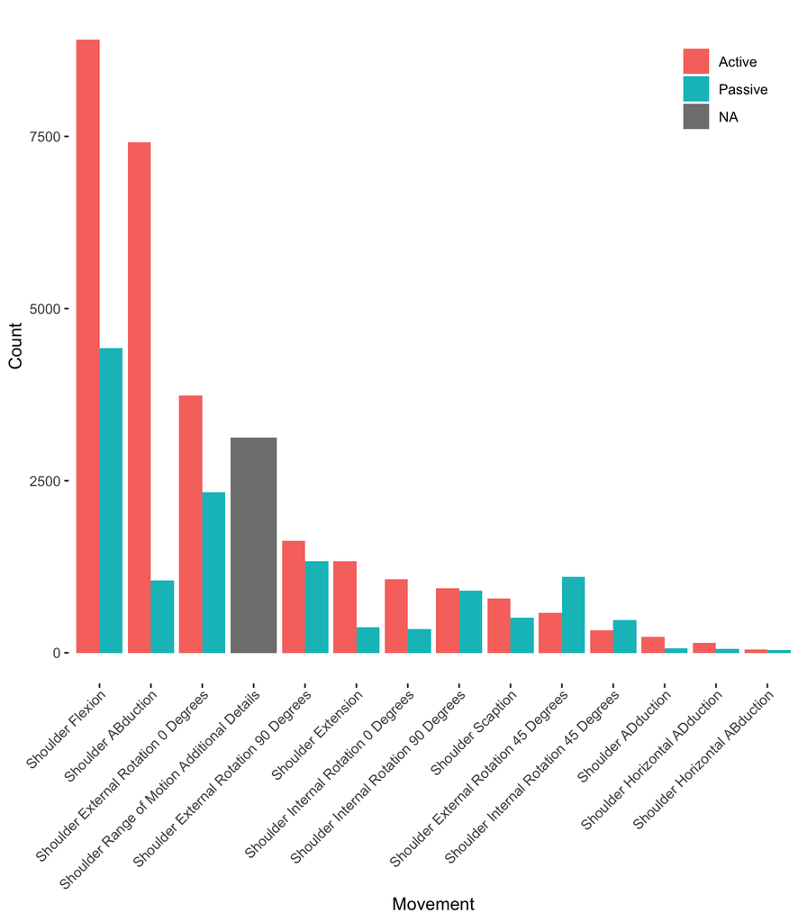

## Within Functional Limits vs Within Normal Limits

Overall “Within Normal Limits” has seen much more use than “Within Functional Limits”. While both were used, this may prompt a decision from Rehab leadership on whether keeping both is necessary or if we can reduce visual clutter and simplify documentation as they have largely overlapping meaning.

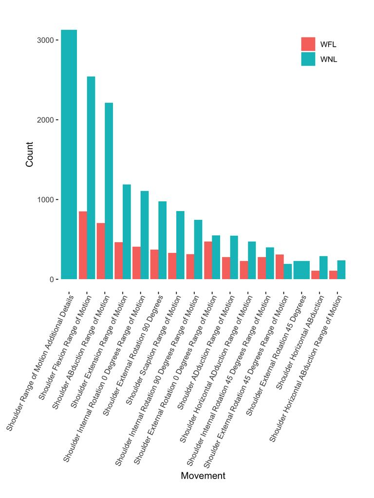

### Comments for WFL and WNL

This plot combines WFL and WNL documentation as well as comments for both. Commenting for WFL and WNL was extremely limited. The ability to remove commenting options would likely help reduce visual clutter without significant impact on documentation ability.

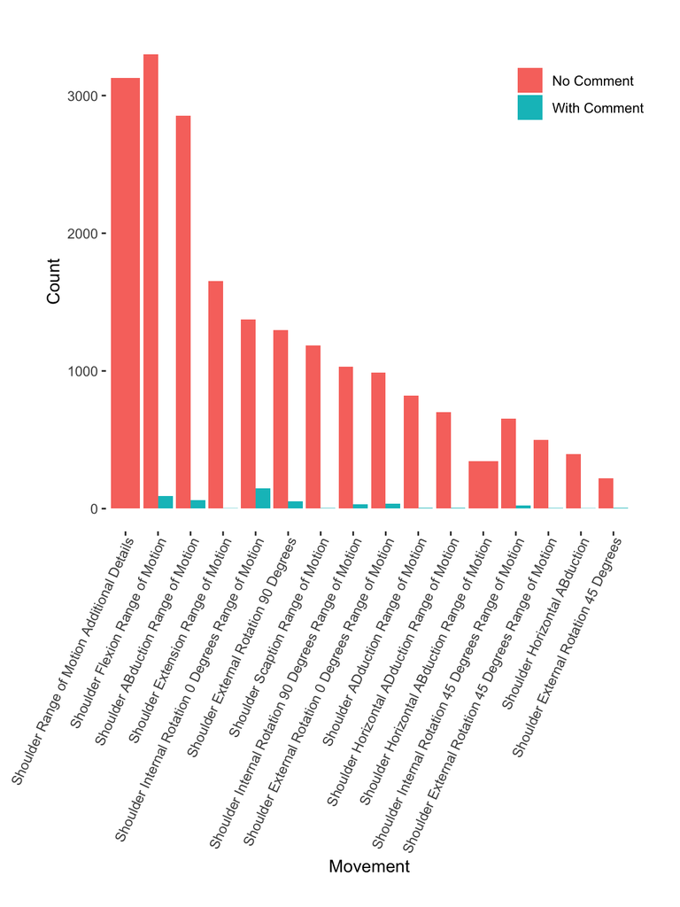

# Clinician ROM Documentation Trends Over Time

This plot trends clinician use of the active and passive number entry boxes over two week intervals. The “Abandoned” group holds clinicians who have documentation during the first month but who haven’t documented at all in the last month of data.

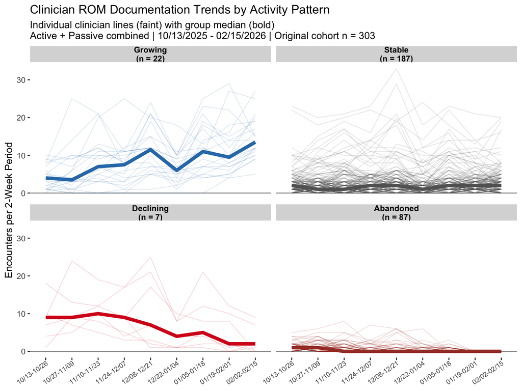

# Additional Details Row: Numeric ROM Documentation

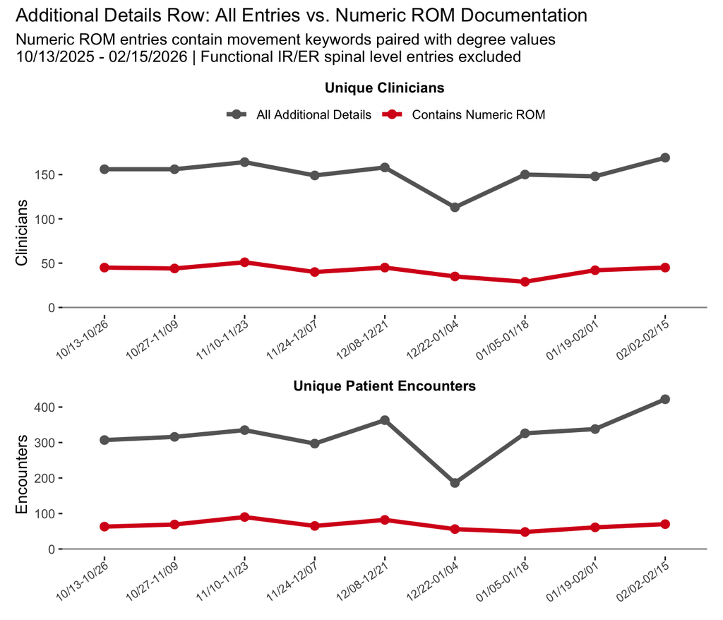

## ROM Documentation Method by Department

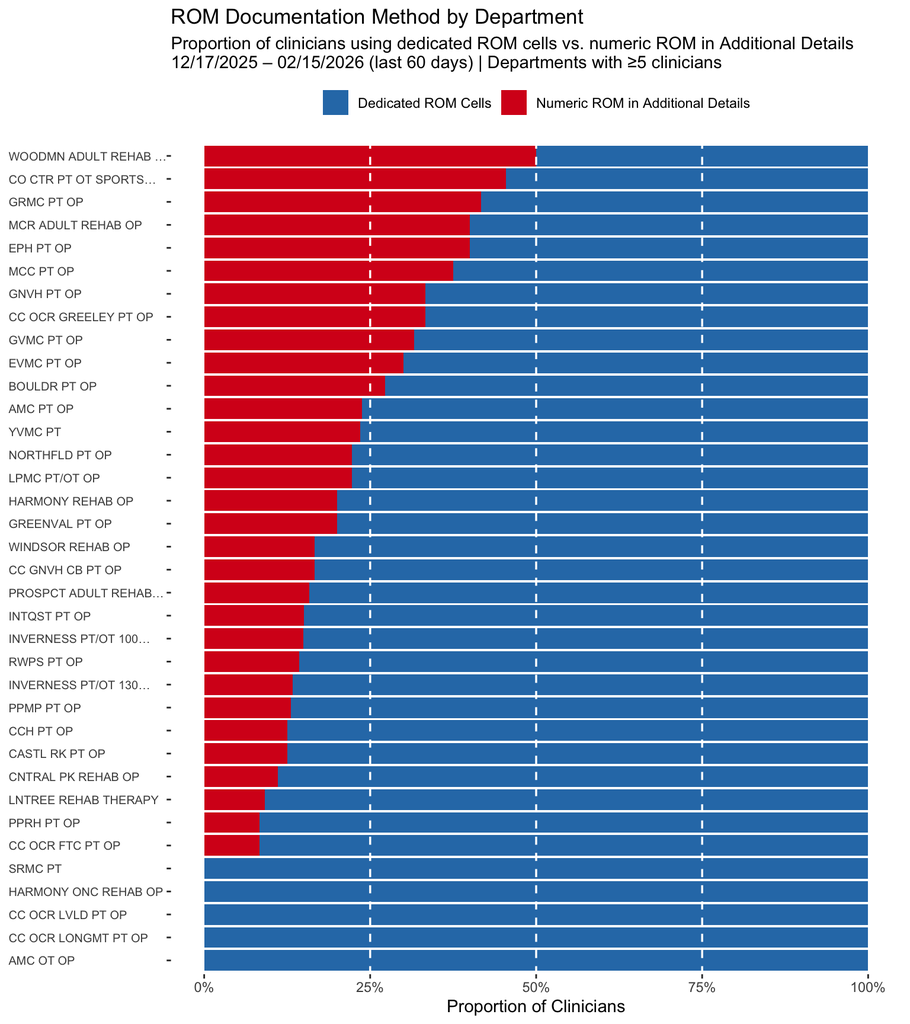

# Appendix

## Additional Details: Numeric ROM Match Reference

Additional Details entries containing numeric ROM values. Only the matched text snippet (with 20 characters of surrounding context) is shown, not the full entry. Note: short keywords (ER, IR) may occasionally match word endings.

Date

Department

Matched Text

2025-10-13

CASTL RK PT OP

oulder AAROM supine flexion: 125d; L shoulder PROM E

2025-10-13

EVMC PT OP

L PROM of shoulder: 135 flexion in scapular

2025-10-13

INVERNESS PT/OT 100 OP

R TUB T7 overhead T5 L TUB T5 overhead

2025-10-13

INVERNESS PT/OT 100 OP

PROM flexion- approx 100 degrees, abd approx

2025-10-13

PPRH PT OP

ft limited for full flexion -15 degrees, limited ER

2025-10-14

BOULDR PT OP

Shoulder FLexion: R 120, L 150. Scaption:

2025-10-14

EVMC PT OP

exion, scaption and abd to 90 degrees. IR to bell

2025-10-14

GRMC PT OP

R:L shoulder abduction 150:155; R:L shoulder flexi

2025-10-14

LNTREE REHAB THERAPY

ROM WNL, (R) Shoulder ROM 165 shoulder flexion, 1

2025-10-14

RWPS PT OP

shld PROM: (supine) flexion 150 deg, ER 65 deg at 4

2025-10-15

AMC PT OP

Shoulder AROM: flex ~65deg B, abd ~65deg B,

2025-10-15

GVMC PT OP

onset of pain AROM flexion >90 degrees, onset of p

2025-10-15

GVMC PT OP

ROM wnl; left elbow extension lacking 20 deg, R lack 10 deg

2025-10-15

INVERNESS NEURO REHAB

ted AROM of L shoulder flexion 85 degrees, abduction

2025-10-15

INVERNESS PT/OT 130 OP

Post: Flx (160), Abd: (140)

2025-10-15

NORTHFLD PT OP

also per doctors orders for 2 weeks.

2025-10-16

AMC PT OP

s to opposite shoulder T4, reaching over same

2025-10-16

BOULDR PT OP

Shoulder AROM: flexion R 155 degrees (pain), L 1

2025-10-16

FOXTRAIL PT OP

AROM shoulders L 130/130/60/T10. R 140/140/

2025-10-16

GRMC PT OP

shoulder flex/scap/abd to 90-100 B with PROM she is

2025-10-16

GVMC PT OP

in with flexion and abduction >90 degrees bilaterally

2025-10-16

PPW PT OP

sly 4- to 4+/5, weaker in C5-7 myotomes. SpTests:

2025-10-17

AMC PT OP

ulder WNLs, L shoulder flex ~95deg, abd ~90deg, ER

2025-10-17

CC GNVH CB PT OP

R shoulder PROM to 110 flexion, 90* abd, 6

2025-10-17

CO CTR PT OT SPORTS OP

all dir; R GHJ AROM flexion 70, abd 52 with pain, Funtion

2025-10-17

FOXTRAIL PT OP

Right shoulder PROM: 90/90 scaption/0/0. No A

2025-10-17

INVERNESS PT/OT 100 OP

nd back largest difference, L T8, R T10

2025-10-17

NORTHFLD PT OP

Right Shoulder Flexion: 155 degrees Extension:

2025-10-17

NORTHFLD PT OP

L shoulder BTH: T4, BTB: T6; R shoulde

2025-10-17

PPW PT OP

Left UE WNL except abd/flex= 90* w/pain. PROM left

2025-10-17

PROSPCT ADULT REHAB OP

- B SLR WNL, B hip ER 35, B hip IR 10, Right

2025-10-17

WOODMN ADULT REHAB OP

houlder Flexion and Abduction Limited ~140 deg and reports of

2025-10-20

AMC PT OP

R shoulder internal rotation 2 inches less than le

2025-10-20

CASTL RK PT OP

PROM shoulder flexion ~140d. Tight shoulder ER

2025-10-20

EPH PT OP

ly. Shoulder AROM: flexion L 124, R 122, abduction tight on

2025-10-20

FOXTRAIL PT OP

AROM shoulders L 155/170/80/T6. R 165/170/

2025-10-20

GRMC PT OP

shoulder flex/scap/abd R 135/135/135, vs L 120/130/1

2025-10-20

MCR ADULT REHAB OP

houlder flexion and abduction 150

2025-10-20

NORTHFLD PT OP

R shoulder BTH: T4, L shoulder BTH: T2

2025-10-21

CC WRIGHT PT OP

Right shoulder flexion: 82 Left shoulder flexi

2025-10-21

INVERNESS PT/OT 100 OP

R Functional IR 5/10 pain at T10 and L a

2025-10-21

NORTHFLD PT OP

Left Shoulder Flexion 160 degrees Abduction 1

2025-10-21

PPW PT OP

M: Right shldr AROM flex=~60*, IR to hip. PROM f

2025-10-22

AMC PT OP

R shoulder flexion 120, ABD 140, painful RBB but ab

2025-10-22

CASTL RK PT OP

R shoulder PROM: 90d. R elbow PROM: ful

2025-10-22

GVMC PT OP

L SHOULDER = flexion to 170 with pain at 90 deg

2025-10-22

LNTREE REHAB THERAPY

teral chest edema, firm with 2+ pitting edema. Flu

2025-10-22

LNTREE REHAB THERAPY

Rounded Shoulders: R 8cm, L: 6cm; HBH ER:

2025-10-23

AMC PT OP

Improved shoulder flexion from ~130 to ~150 after manua

2025-10-23

AMC PT OP

Internal Rotation: R=T11, L=T10

2025-10-23

BOULDR PT OP

shoulder AROM/PROM: Flexion:145/145 with pain. Scaptio

2025-10-23

EVMC PT OP

R shld PROM: flex 10 deg, abd 10 deg, ER

2025-10-23

INVERNESS PT/OT 100 OP

Functional IR up back: 1 inch below inferior

2025-10-23

RWPS PT OP

ly weakness in left abd 4 and pronation 4+/4+

2025-10-24

AMC PT OP

L shoulder HBH: C4, HBB: L3

2025-10-24

BOULDR PT OP

ne for AAROM: Shoulder flexion 100deg, passive ER limi

2025-10-24

EPH PT OP

and IR to sacrum upper or L5 max. Elbows, wrist

2025-10-24

FOXTRAIL PT OP

AROM right shoulder 170/160/75/T10. Left shoulder

2025-10-24

LNTREE REHAB THERAPY

GH AROM flexion L 170 degrees, R 155 degr

2025-10-24

LNTREE REHAB THERAPY

GH AROM flexion R 150 degrees, L 125 with

2025-10-24

NORTHFLD PT OP

eft Shoulder AROM: Flexion: 160 degrees Extension:

2025-10-24

NORTHFLD PT OP

eft Shoulder AROM: Flexion: 160 degrees Extension:

2025-10-24

PPW PT OP

der ROM: R, L shoulder flexion: 170, stiff end range; w

2025-10-25

CO CTR PT OT SPORTS OP

No active (2+ elbow flexion, 1+ deltoid)

2025-10-27

AMC PT OP

Shoulder flexion 160 R, 120 L; ABD 148 R, 120 L

2025-10-27

AMC PT OP

sure into end-range abduction in last 15 deg. Internal rotat

2025-10-27

BOULDR PT OP

Shoulder AROM flexion R 140 degrees, L 150 degr

2025-10-27

BOULDR PT OP

Shoulder AROM flexion R 110 degrees, L 130 degr

2025-10-27

CASTL RK PT OP

oulder AAROM supine flexion: 125d; L shoulder PROM E

2025-10-27

CCH PT OP

er AROM Right shoulder flexion: 148 Left shoulder flexi

2025-10-27

EVMC PT OP

R shld AROM: flex, abd 75 degrees, L shld ARO

2025-10-27

GREENVAL PT OP

Supine AROM: Flexion - 158

2025-10-27

GRMC PT OP

to exs, 50, AB 57, ER 43.

2025-10-27

GRMC PT OP

no restrictions; L flex/scap/abd 135/152/152 all with en

2025-10-28

BOULDR PT OP

ulder AROM R WNL; L flexion 165 degrees, abd 160 de

2025-10-28

BOULDR PT OP

Shoulder AROM flexion R 140 degrees, L 160 degr

2025-10-28

CC GNVH CB PT OP

a IC, Post Tx: ER @ 90: 70, Hor ADD: 35, ABD:

2025-10-28

GVMC PT OP

Shoulder AROM (R/L) Flexion: 160/ 85 Abduction: 140/ 95

2025-10-28

INVERNESS PT/OT 100 OP

pain just sitting here 8/10

2025-10-28

PROSPCT ADULT REHAB OP

12 vs. Right shoulder T8

2025-10-28

WOODMN ADULT REHAB OP

ge PROM; R Shoulder Flexion = ~20 deg; R shoulder IR

2025-10-28

YVMC OT

eries on both shoulders L 2012, R 2021 - bicep ten

2025-10-29

AMC PT OP

s, L shoulder AROM: flex ~85deg, abd ~30deg, ER

2025-10-29

BOULDR PT OP

irections. L shoudler: Flexion 145 with pain/155 with

2025-10-29

BOULDR PT OP

Shoulder AROM flexion R 110 degrees, L 160 degr

2025-10-29

INVERNESS PT/OT 130 OP

nd functional IR // abduction, ER @ 0, and functional ER

2025-10-29

LNTREE REHAB THERAPY

Rounded Shoulders: R 8cm, L: 6cm; HBH ER:

2025-10-29

NORTHFLD PT OP

Right Shoulder Flexion: 130 degrees Extension:

2025-10-29

PPRH PT OP

lanes with painfull ER at 90abduction and painfu

2025-10-30

BOULDR PT OP

Shoulder AROM flexion R 165 degrees, L 165 degr

2025-10-30

GVMC PT OP

AROM: Flexion WNL; Extension 20% motion; SB right 5

2025-10-30

GVMC PT OP

ROM Left WNL; Right Flexion: 100deg with painful pop

2025-10-30

LPMC PT/OT OP

ment in asterisk os ER at 90 ABD AROM and less h

2025-10-30

PPW PT OP

M: Right shldr AROM flex=110* w/pain, ER=50* w/p

2025-10-30

PPW PT OP

M: Right shldr AROM flex=110* w/pain, ER=50* w/p

2025-10-31

GRMC PT OP

Shoulder Flexion 150, Abduction 150, Ext

2025-10-31

INVERNESS PT/OT 100 OP

FIR L: T 10 R: L4

2025-10-31

INVERNESS PT/OT 100 OP

AROM L Shoulder 120 FLX , 105 ABD

2025-10-31

PPW PT OP

MMT: R only; shoulder flexion: 4; shoulder ABD: 4; s

2025-10-31

PROSPCT ADULT REHAB OP

FIR is 2’’ less on right, FE

2025-11-01

CO CTR PT OT SPORTS OP

ight and Left shoulder ER at 0 abduction appears t

2025-11-03

EPH PT OP

NL. Shoulder AROM: flexion R 138, L WNL, abduction R

2025-11-03

EVMC PT OP

ROM - B flexion and abd grossly 120, ER and IR grossly

2025-11-03

GRMC PT OP

scaption, abd; horz abduction 90 dgs, IR 10, ER 30;

2025-11-03

GVMC PT OP

Wall walk: fingers at 5, elbow at 16

2025-11-03

LPMC PT/OT OP

levels in shoulder were around 4-5/10 with the movem

2025-11-03

NORTHFLD PT OP

Left Shoulder Flexion 160 degrees Abduction 1

2025-11-03

PROSPCT ADULT REHAB OP

t shoulder flex and abduct at 160 degrees AROM

2025-11-04

AMC PT OP

ss with L end range flexion, but 180 degrees of flexion

2025-11-04

CC GNVH CB PT OP

Combined flex/ER 1 vertebral level hig

2025-11-04

CNTRAL PK REHAB OP

R shoulder flexion 175, only mild soreness

2025-11-04

FOXTRAIL PT OP

ransition to 90 deg abd to 110

2025-11-04

GRMC PT OP

AROM right shoulder flexion 78, AB 75, ER at side 40.

2025-11-04

GRMC PT OP

Shoulder is stiff. Flexion 110, ER 25, and AB 90 with PRO

2025-11-04

PROSPCT ADULT REHAB OP

to movement, L shld flexion of 95 degrees and abducti

2025-11-05

CO CTR PT OT SPORTS OP

Pre: R flexion 145 L flexion 140 Post:

2025-11-05

EPH PT OP

Shoulder AROM: flexion L 113, R mild decrease, a

2025-11-05

GVMC PT OP

PROM L shoulder: flexion approx 100 deg with minimal pa

2025-11-05

INTQST PT OP

L shoulder AROM: flexion 150 (pain); ABD 90 (pai

2025-11-05

LNTREE REHAB THERAPY

Rounded Shoulders: R 8cm, L: 6cm; HBH ER:

2025-11-05

NORTHFLD PT OP

Right Shoulder Flexion: 140 degrees Extension:

2025-11-05

NORTHFLD PT OP

Right Shoulder Flexion: 155 degrees Extension:

2025-11-05

WOODMN ADULT REHAB OP

R shoulder abduction painful ~90 deg and painful unt

2025-11-06

AMC PT OP

AROM shoulder flexion=70 degrees with compen

2025-11-06

BOULDR PT OP

r AROM flexion bilateral 165 degrees, abd bilate

2025-11-06

GVMC PT OP

R shoulder flexion AAROM 153 degrees ( post manu

2025-11-06

PROSPCT ADULT REHAB OP

FIR is 3’’ less on right, FE

2025-11-06

WOODMN ADULT REHAB OP

ervical AROM flex, ext, rot R 72 , rot L 58, SB R 15

2025-11-07

CC GNVH CB PT OP

Shoulder AROM: Flexion 155B, ABD 145 B, ER WNL

2025-11-07

CNTRAL PK REHAB OP

L shoulder PROM flexion: 145, AROM flexion 114

2025-11-07

EPH PT OP

pain at end range, IR WNL, ER 35 deg and painful. R

2025-11-07

EVMC PT OP

Hx of R reverse TSA in 2017

2025-11-07

GRMC PT OP

is able to tolerate flexion to 100, abduction to 90 an

2025-11-07

GRMC PT OP

Her PROM flexion 95, 15 ER at side. No har

2025-11-10

CASTL RK PT OP

Internal rotation: to L4

2025-11-10

CO CTR PT OT SPORTS OP

ss R GH joint, PROM IR at 90 deg abd supine = 0-

2025-11-10

EPH PT OP

which is 40 deg. R flexion 126, abduction 111, IR

2025-11-10

GNVH PT OP

OM at 45 and 90 deg ABD - has 70-80 deg ER; PROM at 0 d

2025-11-10

GRMC PT OP

PROM today 120 flexion, 30 ER. Sore with ER.

2025-11-10

HARMONY REHAB OP

Pain with abduction on R > 100 deg. Mild pain/stif

2025-11-10

INTQST PT OP

PROM into shoulder flexion to ~120 degrees, bilaterall

2025-11-10

PPW PT OP

M: Right shldr AROM flex/abd=90* w/pain. AAROM to ~

2025-11-11

BOULDR PT OP

Shoulder AROM flexion R 170 degrees, L 140 degr

2025-11-11

BOULDR PT OP

Shoulder AROM flexion R 155 degrees, L 170 degr

2025-11-11

CO CTR PT OT SPORTS OP

Shoulder ROM Pre: flexion: 120 Post: 142

2025-11-11

CO CTR PT OT SPORTS OP

R shoulder flexion 95, scaption 95, ER 75

2025-11-11

GRMC PT OP

AROM shoulder flexion 105, AB 110, ER 45 prior to exs

2025-11-11

INVERNESS PT/OT 100 OP

l arc with shoulder abduction to 80* unable to continue

2025-11-11

NORTHFLD PT OP

eft Shoulder AROM: Flexion: 160 degrees Extension:

2025-11-11

NORTHFLD PT OP

eft Shoulder AROM: Flexion: 160 degrees Extension:

2025-11-11

PPMP PT OP

R shoulder ROM: 150 deg Flex, 150 deg A

2025-11-11

WOODMN ADULT REHAB OP

L Shoulder AROM: Flexion = ~110 deg, abduction = ~7

2025-11-12

AMC PT OP

AROM flexion 90 R, 152 L; ABD 78 R, 130 L

2025-11-12

AMC PT OP

MMT- shoulder flex: L=5/5, R=4/5; shoulder e

2025-11-12

AMC PT OP

sment): flexion and abduction to 145 deg bilaterally. La

2025-11-12

CC GNVH CB PT OP

guarding on L side FIR: (L) 1 hand width below co

2025-11-12

CC GNVH CB PT OP

OM, pre tx: seated- flexion to 170, abduction to 170 -

2025-11-12

EVMC PT OP

houlder flexion and abd > 90 degrees

2025-11-12

GNVH PT OP

Shoulder flexion R 160 with compensatory s

2025-11-12

LPMC PT/OT OP

r flexion. Shoulder abduction approx 20-30*. Able to flex a

2025-11-12

NORTHFLD PT OP

Right Shoulder Flexion: 140 degrees Extension:

2025-11-12

NORTHFLD PT OP

Right Shoulder Flexion: 160 degrees Extension:

2025-11-12

NORTHFLD PT OP

Right Shoulder Flexion: 160 degrees Extension:

2025-11-12

RWPS PT OP

Fingers ext about 35 degrees and passive

2025-11-13

AMC PT OP

R shoulder AROM flexion 142, 158 R, ABD 136, 160 L;

2025-11-13

AMC PT OP

Right shoulder flexion 127 active assisted ran

2025-11-13

CC GNVH CB OT OP

Bil shoulder extension AROM: 50 deg; IR BUE: WNL AR

2025-11-13

EVMC PT OP

R shoulder 40% limited with flexi

2025-11-13

GNVH PT OP

Shoulder flexikon R 150 L 160.

2025-11-13

GVMC PT OP

AAROM pulleys L flexion 100 pre-treatment; AARO

2025-11-13

INVERNESS PT/OT 100 OP

Flexion approx 100 degrees, abd approx

2025-11-13

INVERNESS PT/OT 130 OP

R shld supine flexion 155, standing 140

2025-11-13

PPW PT OP

ain. PROM in supine flex ~80*, ER ~40* pain at e

2025-11-14

CNTRAL PK REHAB OP

L shoulder PROM flexion: 151, AROM flexion: 115,

2025-11-14

GRMC PT OP

AROM right shoulder flexion 120, AB 100, ER 30. Left shoul

2025-11-14

NORTHFLD PT OP

Left shoulder AROM Flexion 160 degrees Extension 5

2025-11-14

NORTHFLD PT OP

Right Shoulder Flexion: 160 degrees Extension:

2025-11-14

PPW PT OP

ROM for L shoulder: flexion: 60, ER: -10; ABD NT.

2025-11-14

YVMC PT

ot tested. PROM- 90 flexion, 45 degrees ABD, Neutra

2025-11-15

CNTRAL PK REHAB OP

patient was able to flex to 140 and abduct to 130 w

2025-11-17

CC GNVH CB PT OP

ed post-TX: FF 140, ABD 140, IR 60, ER 75, Hor ADD 42

2025-11-17

FOXTRAIL PT OP

AROMShoulders bilat 160/170/80/T6.

2025-11-17

GNVH PT OP

Shoulder Flexion R/L 180

2025-11-17

GRMC PT OP

PROM for shoulder ER is 10, flexion 100 end of

2025-11-17

GRMC PT OP

11-17 PROM flexion 120, ER 30, AB 110.

2025-11-17

NORTHFLD PT OP

Right Shoulder Flexion: 155 degrees Extension:

2025-11-17

NORTHFLD PT OP

Left shoulder AROM Flexion 160 degrees Extension 5

2025-11-17

NORTHFLD PT OP

Left Shoulder Flexion 160 degrees Abduction 1

2025-11-18

AMC PT OP

RUE limited flexion PROM to 90deg, LUE limited fle

2025-11-18

CC GNVH SPN PT OP

Functional Internal Rotation: R L3, L T8 (Right was

2025-11-18

GRMC PT OP

al IR/ER for R shouler C7:L4; IR/ER for L should

2025-11-18

GRMC PT OP

AROM left shoulder flexion 110, AB 105, ER at side 50.

2025-11-18

GRMC PT OP

L shoulder AROM Flexion 150, Abduction 140, Ext

2025-11-18

INTQST PT OP

B shoulder flex to ~ 140 degrees; ABD to ~ 1

2025-11-18

NORTHFLD PT OP

eft Shoulder AROM: Flexion: 160 degrees Extension:

2025-11-18

NORTHFLD PT OP

Left shoulder AROM Flexion 160 degrees Extension 5

2025-11-18

PPW PT OP

OM: Left shldr PROM Flex ~100*, ER~40*, Abd~90*.

2025-11-18

WINDSOR REHAB OP

flexion - R 142 P!, L 125 P!, abd -

2025-11-18

WOODMN ADULT REHAB OP

/limited L shoulder abduction ~85 deg, IR behind back

2025-11-19

AMC PT OP

L shoulder flexion 115, ABD 105. After manual, fle

2025-11-19

CNTRAL PK REHAB OP

L shoulder PROM flexion: 160, AROM flexion:

2025-11-19

EPH PT OP

Shoulder: AROM flexion L 113 pain, R 129 pain, a

2025-11-19

EVMC PT OP

ly limited with ER, flexion; 50%NL for R shld abduc

2025-11-19

INVERNESS PT/OT 100 OP

*PROM* Right Shoulder Flexion: 170 Left Shoulder Flexi

2025-11-19

LPMC PT/OT OP

L shoulder RBH T4; RBB T7

2025-11-19

MID VALLEY SPORTS MED

90 degrees abduction and 140 degrees flexion inc

2025-11-19

NORTHFLD PT OP

Right Shoulder Flexion: 140 degrees Extension:

2025-11-19

NORTHFLD PT OP

Right Shoulder Flexion: 160 degrees Extension:

2025-11-19

NORTHFLD PT OP

Left shoulder AROM Flexion 160 degrees Extension 5

2025-11-19

PPMP PT OP

At IE: R shoulder ROM: 130 deg Flex, 120 deg A

2025-11-19

PPRH PT OP

R shoulder PROM flexion 70 degrees with pain a

2025-11-19

PPW PT OP

AROM/PROM: L shoulder flexion: 160/170 discomfort at e

2025-11-19

WOODMN ADULT REHAB OP

L shoulder PROM: flexion to 85, ER to neutral, IR

2025-11-20

AMC PT OP

Right shoulder flexion 131 active assisted ran

2025-11-20

CC GNVH CB PT OP

Post -TX FF 153, ABD 155

2025-11-20

GRMC PT OP

AROM right shoulder flexion 105, AB 110, ER 30. PRIOR to

2025-11-20

LNTREE REHAB THERAPY

lder AROM screened: flexion: right ~90 deg, left ~110 deg,

2025-11-20

PPMP PT OP

Shoulder flex 120 AAROM, abduction 11

2025-11-20

PPMP PT OP

lder WNL’s, L shoulder flex 140 deg, abd 142, ER 67

2025-11-20

PROSPCT ADULT REHAB OP

Shldr flex R 150 L 112, abd R 110 with pai

2025-11-21

AMC PT OP

L (active/passive) flex 124/165, abd 90/100, ER 50

2025-11-21

AMC PT OP

metry measurements were taken 2/2 safe handling of pa

2025-11-21

GRMC PT OP

OM end of session. Flexion 120, AB 110, ER 55.

2025-11-21

GRMC PT OP

AROM Flexion 130, Abduction 130, Extension 40, Int

2025-11-21

LPMC PT/OT OP

140 deg flexion and abduction L 2’ to stiffness and p

2025-11-21

PPMP PT OP

PROM only R shoulder: flexion 120, abduction 90, ER 2

2025-11-21

PPMP PT OP

Shoulder PROM 70 deg flex/ 40 deg ab

2025-11-24

AMC PT OP

R shoulder flexion 160, ABD 150, reach behind head

2025-11-24

CC GNVH CB PT OP

Post -TX FF 154, ABD 150, ER 80, IR 60 Hor ADD 45

2025-11-24

CO CTR PT OT SPORTS OP

uction; flexion and abduction 5-8 degrees less vs L a

2025-11-24

GRMC PT OP

AAROM dowel supine flexion 125. She does hike sho

2025-11-24

GRMC PT OP

AROM Flexion 160, abduction 155, Ext ROT 85, Int RO

2025-11-24

GVMC PT OP

Shoulder abduction active 110 degrees, passive 13

2025-11-24

INVERNESS PT/OT 100 OP

the whole motions; ext hurts L>90 abd, R 120 cross bo

2025-11-24

INVERNESS PT/OT 100 OP

motions; AROM L>90 abd, R 120; cross body good bu

2025-11-24

LNTREE REHAB THERAPY

cept: left shoulder flexion lacking 20 deg from full AROM,

2025-11-24

RWPS PT OP

nful at 90 degrees, abduction 80 degrees with pain,

2025-11-24

WOODMN ADULT REHAB OP

M ~105 deg; L shoulder ER = ~25-30 deg

2025-11-25

AMC PT OP

visual assessment): flexion 110 deg, abduction 90 d

2025-11-25

CASTL RK PT OP

h equal to L. 90/90 ER, 60d bil and “tight” on

2025-11-25

CNTRAL PK REHAB OP

L shoulder PROM flexion: 160, AROM flexion 116

2025-11-25

GNVH PT OP

Shoulder flexion 170

2025-11-25

GRMC PT OP

ling with end range ER and 90*. Pt no longer conc

2025-11-25

GVMC PT OP

range R), shoulder IR limited 10% pain end range ant

2025-11-25

GVMC PT OP

Supine AAROM L flexion w dowel: 140

2025-11-25

INVERNESS PT/OT 100 OP

PROM ER 45 degrees

2025-11-25

NORTHFLD PT OP

eft Shoulder AROM: Flexion: 160 degrees Extension:

2025-11-25

NORTHFLD PT OP

eft Shoulder AROM: Flexion: 160 degrees Extension:

2025-11-26

AMC PT OP

L shoulder AROM flexion 120, ABD 120. After manual, fle

2025-11-26

CO CTR PT OT SPORTS OP

Shoulder PROM: flexion 95, scaption 40, ER 5,

2025-11-26

NORTHFLD PT OP

Right Shoulder Flexion: 160 degrees Extension:

2025-11-26

NORTHFLD PT OP

Right Shoulder Flexion: 160 degrees Extension:

2025-11-26

PPRH PT OP

PROM L shou: flex 140 deg, scaption, WFL,

2025-11-28

AMC PT OP

ll motions. R shoulder flex 152deg, abd 150deg, ER

2025-11-28

GRMC PT OP

AROM Flexion, Abducton 170, EXT ROT 80, Int RO

2025-11-28

GRMC PT OP

Shoulder AROM flexion 95, AB 75, ER at side 15 prio

2025-12-01

CC GNVH CB PT OP

Post -TX FF 160, ABD 160, ER 86, IR 65 Hor ADD 45

2025-12-01

CNTRAL PK REHAB OP

L shoulder PROM flexion: 150, AROM flexion 118

2025-12-01

EPH PT OP

der AROM: L WNL. R flexion 29, abduction 23, limi

2025-12-01

FOXTRAIL PT OP

oulder. Left shoulder 165/170/80/WNL.. PROM right e

2025-12-01

GRMC PT OP

AROM flexion 110, AB 112, ER at side 20.

2025-12-01

INVERNESS PT/OT 100 OP

Can feel end range abd - mainlu 70-90 lateral shoulder

2025-12-01

INVERNESS PT/OT 100 OP

Can feel end range abd - mainly 70-90 lateral shoulder

2025-12-01

INVERNESS PT/OT 100 OP

Can feel end range abd - mainly 70-90 lateral shoulder

2025-12-01

LPMC PT/OT OP

AROM: flexion 75% pain, abduction WF

2025-12-01

PPRH PT OP

WNL. PROM L shou: flex 70 deg, scaption 70 de

2025-12-01

PPW PT OP

OM: Left shldr PROM flex=90*, Abd=70*, ER to 0*. STR: Le

2025-12-01

RWPS PT OP

orm R overhead. L overhead to C7.

2025-12-02

AMC PT OP

L shoulder AROM flexion 120, ABD 110. After manual, fle

2025-12-02

CC GNVH SPN PT OP

functional reach of IR and 90 deg abd position 20

2025-12-02

CNTRAL PK REHAB OP

R shoulder PROM: ER to 65 degrees, Abduction

2025-12-02

CO CTR PT OT SPORTS OP

Shoulder ER AROM at 0 deg: 42 deg

2025-12-02

EVMC PT OP

~ 100 degrees shoulder flexion, 90 degrees abduction,

2025-12-02

FOXTRAIL PT OP

AROm shoulders 125 deg due to pain. A

2025-12-02

GRMC PT OP

AROM left shoulder flexion 70, AB 70, ER 10

2025-12-02

GRMC PT OP

PROM flexion 120, scaption 110, ER a

2025-12-02

INVERNESS PT/OT 100 OP

and posterior shoulder , FIR L: 2 levels past inf ang

2025-12-02

NORTHFLD PT OP

Left Shoulder Flexion 160 degrees Abduction 1

2025-12-02

PROSPCT ADULT REHAB OP

R functional IR limited 3-4 inches compared t

2025-12-03

CNTRAL PK REHAB OP

R shoulder AROM flexion: 90, abduction: 75

2025-12-03

GVMC PT OP

motion decreased: R abduction approx 90 deg, L abduction ap

2025-12-03

NORTHFLD PT OP

Right Shoulder Flexion: 160 degrees Extension:

2025-12-03

NORTHFLD PT OP

Right Shoulder Flexion: 160 degrees Extension:

2025-12-03

PROSPCT ADULT REHAB OP

FIR equal B, FER 2’’ less on left.

2025-12-03

RWPS PT OP

forward flexion and abduction to 90°, external rotation

2025-12-04

AMC PT OP

AROM flexion 90 R, 152 L; ABD 78 R, 130 L

2025-12-04

AMC PT OP

AAROM shoulder flexion: 111d

2025-12-04

GRMC PT OP

L shoulder Flexion 70, Abduction 70, Exte

2025-12-04

GVMC PT OP

on); pain with PROM IR at 90 deg ABD, able to re

2025-12-04

GVMC PT OP

130, same scaption, abd 90-110, er 70-80, WFL wris

2025-12-04

HAYDEN SPORTS MED OP

ach behind head T1 versus L T3

2025-12-04

PROSPCT ADULT REHAB OP

FIR and FER are 5’’ less on left comp

2025-12-05

GRMC PT OP

AROM Flexion 160, Abduction 150 with pain, Ext ROT

2025-12-05

LPMC PT/OT OP

Able to flex shoulder approx 90. Full ROM in abduct

2025-12-05

NORTHFLD PT OP

Left shoulder AROM Flexion 160 degrees Extension 5

2025-12-05

PPW PT OP

M: PROM Right shldr flex!120*, abd~90*, ER~30*.

2025-12-05

PPW PT OP

der ROM: R, L shoulder flexion: 170, slight discomfort

2025-12-06

INVERNESS PT/OT 100 OP

R ER 150* after intervention

2025-12-08

CC GNVH CB PT OP

Post -TX FF 160, ABD 160, ER 86, IR 65 Hor ADD 45

2025-12-08

WOODMN ADULT REHAB OP

AROM shoudler flex R 70 mod pain L 100 less

2025-12-09

AMC PT OP

visual assessment): flexion to 140 deg, abduction to 1

2025-12-09

BOULDR PT OP

L shoulder PROM tolerated to 80 deg flexion and to

2025-12-09

CNTRAL PK REHAB OP

R shoulder PROM: ER to 72 degrees, Abduction

2025-12-09

EPH PT OP

PROM: L WNL. R flexion 10 deg, abduction 54,

2025-12-09

GRMC PT OP

PROM for flexion 70, ER at side 10

2025-12-09

GVMC PT OP

Passive shoulder flexion 94 degrees, ER 20 degr

2025-12-09

GVMC PT OP

ainful. PROM ER and IR at 90 deg WFL and nonpain

2025-12-10

BOULDR PT OP

teral shoulder AROM flexion R 70 degrees, L 150 degr

2025-12-10

BOULDR PT OP

Shoulder AROM flexion R 170 degrees, L 140 degr

2025-12-10

CNTRAL PK REHAB OP

R shoulder AROM flexion: 115, abduction: 86; PRO

2025-12-10

CNTRAL PK REHAB OP

R shoulder PROM: flexion 160, abduction 115, ER

2025-12-10

CO CTR PT OT SPORTS OP

1” less vs L, PROM IR at 90 deg abd supine = 0-

2025-12-10

CO CTR PT OT SPORTS OP

Shoulder ROM Flexion Pre: 154 Post 165 ER Pre 30

2025-12-10

GRMC PT OP

AROM prior to exs, flexion 78, AB 78, ER 14. AFTER exs

2025-12-10

GRMC PT OP

12-10 AROM shoulder flexion 54, AB 50, ER 0 prior

2025-12-10

HARMONY ONC REHAB OP

Shoulder flexion just to 90 degrees per surgeon

2025-12-10

INVERNESS PT/OT 100 OP

No shoulder ROM x 6 weeks

2025-12-10

WOODMN ADULT REHAB OP

R shoulder AROM: flexion 140 deg painful, abduct

2025-12-11

AMC PT OP

L shoulder HBH: T2, HBB: T12

2025-12-11

BOULDR PT OP

Shoulder AROM flexion R 170 degrees, L 140 degr

2025-12-11

FOXTRAIL PT OP

AROM left shoulder 140/100/60/T8. Right shoulder

2025-12-11

GREENVAL PT OP

ddle traps 3+/5, lower traps 3/5

2025-12-11

GVMC PT OP

Shoulder AROM: flexion - approx 120 bilat; abduction -

2025-12-11

INTQST PT OP

R shoulder PROM: flexion to 60 deg, ER to 5 deg

2025-12-11

MCC PT OP

Pulleys AAROM 135 flexion, and 105 abduction

2025-12-11

PPMP PT OP

but with pain with flex/abd at >90 degrees. B elbow an

2025-12-11

PPW PT OP

Right shoulder AROM flex/Abd=90* w/pain, AAROM = 12

2025-12-11

RWPS PT OP

Supine flexion: R 135 deg, L 130 deg. Ele

2025-12-12

CC GNVH CB PT OP

FIR: (R) 1 hand width above IC

2025-12-12

CNTRAL PK REHAB OP

L shoulder PROM flexion: 150, AROM flexion stand

2025-12-12

GRMC PT OP

AROM for shoulder flexion 70, AB 75, ER 55.

2025-12-12

GRMC PT OP

AROM flexion 150, AB 150 bilaterally. Limit

2025-12-12

GRMC PT OP

AROM prior to exs, flexion 115, AB 125, ER 15.

2025-12-12

GVMC PT OP

R shldr limit IR 0 , ER 0-10, FF 80-90 w/ mild s

2025-12-12

PPMP PT OP

houlder. PROM L GHJ flex to 80 degrees, Abd to 60

2025-12-12

RWPS PT OP

d ROM restrictions: flexion to 90 deg, ER to neutral.

2025-12-12

WOODMN ADULT REHAB OP

ulder AROM: painful flexion 130 deg, abduction 90 d

2025-12-13

INVERNESS PT/OT 130 OP

Behind back T12 versus T4, shoulder flexion/a

2025-12-15

CCH PT OP

er AROM Right shoulder flexion: 148 Left shoulder flexi

2025-12-15

EPH PT OP

PROM shoulder flexion 90, ER 22deg. AROM shoulder E

2025-12-15

EVMC OT OP

ld only bring shoulders to 90*. Seated 135 and si

2025-12-15

GRMC PT OP

AROM prior to exs, flexion 57, AB 50, ER 0

2025-12-15

HARMONY ONC REHAB OP

R shoulder flexion: 155deg, L shoulder flex

2025-12-15

HARMONY ONC REHAB OP

R shoulder flexion: 155deg, L shoulder flex

2025-12-15

INVERNESS PT/OT 100 OP

st op precautions - Flexion 70 degrees AA/PROM, ER

2025-12-15

PROSPCT ADULT REHAB OP

AROM shldr flex L 110, R 118, abd L 120 R 110, E

2025-12-15

RWPS PT OP

head scratch R=L. R ER tight at 90 deg abduction compa

2025-12-16

AMC PT OP

visual assessment): flexion to 150, abduction to 145 d

2025-12-16

BOULDR PT OP

r AROM flexion bilateral 150 degrees, abd bilate

2025-12-16

CC GNVH CB PT OP

tion limited 20% B, extension limited 20%

2025-12-16

CNTRAL PK REHAB OP

R shoulder PROM: flexion 170, abduction 140, ER

2025-12-16

CO CTR PT OT SPORTS OP

lder AROM Pre/Post: Flexion Pre: 110 Post: 145

2025-12-16

GRMC PT OP

AROM flexion 110, AB 107, ER at side 25.

2025-12-16

INVERNESS PT/OT 100 OP

- painfree shoulder flexion to 160*

2025-12-16

PPMP PT OP

WNL’s, except L GHJ abd 110 deg, ER 55 deg L vs

2025-12-16

PPW PT OP

M: Left shldr AAROM flex ~70*, ER= 0*. PROM flex

2025-12-17

AMC PT OP

er scaption to 130, flexion 120, both with UT subst

2025-12-17

BOULDR PT OP

R shoulder PROM flexion 90 degrees, abd 80 deg

2025-12-17

CC HULETT PT OP

R wrist flexion 86, extension 74, RD 15 UD 45; L wrist flex

2025-12-17

GRMC PT OP

AROM right shoulder flexion 105, Ab 100, ER at side 35

2025-12-17

HARMONY REHAB OP

uced with end range flexion, with 90 deg abduction and o

2025-12-17

INVERNESS NEURO REHAB

Cervical flexion 50% with tremor presen

2025-12-17

LPMC PT/OT OP

imited. BB IR shoulder: S2 to midline, painful

2025-12-17

WOODMN ADULT REHAB OP

0 deg from neutral, Flexion = 30 deg

2025-12-18

CO CTR PT OT SPORTS OP

ulder ROM PRE/POST: Flexion Pre 154 POST: 165

2025-12-18

FOXTRAIL PT OP

: right flexion and abduction 150, ER and 90 abductio

2025-12-18

GNVH PT OP

73lbs Pincer Grasp: R 22lbs L 26lbs

2025-12-18

GRMC PT OP

AROM left shoulder flexion 111, Ab 58, ER at side 46. AF

2025-12-18

GRMC PT OP

AROM flexion 145, AB 140, ER 40, ERA 70, IRA

2025-12-18

INVERNESS PT/OT 100 OP

*PROM* Right Shoulder Flexion: 170 Left Shoulder Flexi

2025-12-18

INVERNESS PT/OT 100 OP

AROM abd approx 80-120 painful- pain w

2025-12-18

WOODMN ADULT REHAB OP

PROM R shoulder: flexion 125 deg, ABD 100 deg, E

2025-12-19

CNTRAL PK REHAB OP

L shoulder PROM flexion: 155, AROM flexion stand

2025-12-19

NORTHFLD PT OP

Left shoulder AROM Flexion 160 degrees Extension 5

2025-12-19

PPW PT OP

AROM/PROM: L shoulder flex: 40/110; ABD: 10/90; ER: 20

2025-12-19

PPW PT OP

es. PROM left shldr flex ~110*, ER ~20*. Pts Righ

2025-12-19

PPW PT OP

shoulder AROM/PROM: flexion: 40/100; ER: functional sid

2025-12-19

PPW PT OP

PROM: R, L shoulder flexion: wnl, 90/120; shoulder ABD: wnl,

2025-12-19

PPW PT OP

M L shoulder: shoulder flex 80 degrees; shoulder e

2025-12-20

CNTRAL PK REHAB OP

R shoulder AROM flexion:160; abduction: 115 PRO

2025-12-20

INVERNESS PT/OT 100 OP

R shoulder flexion lacking ~10 deg compared to L

2025-12-22

AMC PT OP

r ipsilateral shoulder T1 on L, T3 on R, reac

2025-12-22

AMC PT OP

R shoulder PROM flex 20, scaption 90, ER 10

2025-12-22

BOULDR PT OP

Shoulder AROM flexion R 130 degrees, L 155 degr

2025-12-22

GRMC PT OP

AROM prior to exs, flexion 64, AB 55, ER 8. AFTER exs,

2025-12-22

MCC PT OP

Shoulder flexion 25-50% tight bilaterally

2025-12-22

NORTHFLD PT OP

Left shoulder AROM Flexion 160 degrees Extension 5

2025-12-22

NORTHFLD PT OP

Left shoulder AROM Flexion 160 degrees Extension 6

2025-12-22

WOODMN ADULT REHAB OP

PROM L shoulder flex 90 deg, IR eyeballed 4

2025-12-22

YVMC PT

aption- 45 degrees, ER- 10 degrees

2025-12-22

YVMC PT

Decreased Shoulder flexion (140), Abduction (120),

2025-12-23

CO CTR PT OT SPORTS OP

Bilateral shoulder flexion AROM = 0-158, abd = 0-148, ER in

2025-12-23

CO CTR PT OT SPORTS OP

uction; flexion and abduction 5-8 degrees less vs L a

2025-12-23

GRMC PT OP

R Elbow 0 degrees, Flexion 130 degrees. Pronation-

2025-12-23

GRMC PT OP

Left shoulder AROM flexion 95, AB 80, ER 10. Hiking pre

2025-12-23

INVERNESS PT/OT 100 OP

L shoulder PROM ~100 post manual interve

2025-12-23

LNTREE PRIM CARE PT OP

L shdr: ER at side, IR at 45 deg ABD, FLEX all r

2025-12-23

MCC PT OP

er ER with shoulder abduction at 90 and below in area o

2025-12-23

PPRH PT OP

PROM R shou: flex 150 deg, scaption appro

2025-12-23

WOODMN ADULT REHAB OP

Cervical AROM flex 45, ext 40, rot R 50 tight , r

2025-12-24

EPH PT OP

axing well. Did exercises 5-10 of each. Did pass

2025-12-24

GRMC PT OP

12-24. AROM flexion 150, AB 155, ER side 56, ER wit

2025-12-24

GRMC PT OP

AROM flexion 105, AB 110, ER 60 PRIOR to exs

2025-12-24

WOODMN ADULT REHAB OP

atus. PROM Shoulder Flexion to 45 degrees, guarding p

2025-12-26

CNTRAL PK REHAB OP

R shoulder AROM abduction: 130, PROM abduction ~17

2025-12-26

CNTRAL PK REHAB OP

L shoulder PROM flexion: 155, AROM flexion stand

2025-12-26

FOXTRAIL PT OP

ransition to 90 deg abd to 110

2025-12-26

GRMC PT OP

AROM flexion 160, AB 165, ER at side 65, ERA

2025-12-26

GRMC PT OP

AROM right shoulder flexion 90, AB 80

2025-12-26

INVERNESS PT/OT 100 OP

was able to do closer to 60 degrees

2025-12-26

WOODMN ADULT REHAB OP

Right Shoulder PROM 90 degrees flexion and

2025-12-27

INVERNESS PT/OT 100 OP

AROM abd approx 80-120 painful- pain w

2025-12-29

CCH PT OP

er AROM Right shoulder flexion: 148 Left shoulder flexi

2025-12-29

EPH PT OP

AROM: shoulder flexion L 140 with significant ti

2025-12-29

FOXTRAIL PT OP

AROM shoulders right: 100/60/70/sacrum ROM li

2025-12-29

GRMC PT OP

ulder to apprix 75* flexion and 10* adbuction; L elbow

2025-12-29

GRMC PT OP

29 AROM after exs, flexion 65, AB 55, ER 15. PROM after

2025-12-29

MCR ADULT REHAB OP

Wrist extension 29*, wrist flexion 33*

2025-12-29

WOODMN ADULT REHAB OP

ulder sitting AROM flex R 67 ( supine 135) pain

2025-12-30

BOULDR PT OP

Shoulder AROM flexion R 150 degrees, L 160 degr

2025-12-30

CO CTR PT OT SPORTS OP

R flexion 120, abduction 140, 60 ER. Passive range o

2025-12-30

GRMC PT OP

AROM flexion 120, AB 115, ER at side 30 PRIO

2025-12-30

GVMC PT OP

k: R to L3, L to lateral L5 with pain and slow

2025-12-30

INVERNESS PT/OT 130 OP

after tx -10

2025-12-30

PMC YMCA PT OP

PROM for the first 4 weeks.

2025-12-30

WINDSOR REHAB OP

ional IR of L shoulder to T12, L to T4

2025-12-31

AMC PT OP

L shoulder PROM: flexion to 130, ER to 20 as per pr

2025-12-31

BOULDR PT OP

Shoulder AROM flexion R 130 degrees, L 130 degr

2025-12-31

FOXTRAIL PT OP

150, scaption 160, ER at 90=90,. IR 90=70. (L sho

2025-12-31

GREENVAL PT OP

Seated shoulder flexion: 80d

2025-12-31

GRMC PT OP

OM normal. Flexion, abduction 160, Er 85, IR 85 degrees. She

2025-12-31

GRMC PT OP

AROM right shoulder flexion 60, AB 65, ER 30.

2025-12-31

PROSPCT ADULT REHAB OP

AROM L shoulder to 70 degrees flex and sc

2026-01-02

CC GNVH CB PT OP

IR post-Tx: 90 degrees ABD, 65, F

2026-01-02

GVMC PT OP

M = WFL flexion and abduction to 180, behind the back to

2026-01-02

INVERNESS PT/OT 130 OP

Painful arch with flexion from 100-130. Apley R T7, L T10

2026-01-02

LPMC PT/OT OP

r flexion. Shoulder abduction approx 20-30*. Able to flex a

2026-01-02

NORTHFLD PT OP

Left shoulder AROM Flexion 160 degrees Extension 6

2026-01-05

BOULDR PT OP

Shoulder AROM flexion R 130 degrees, L 150 degr

2026-01-05

EPH PT OP

Shoulder AROM flexion L 123 severe pain and com

2026-01-05

FOXTRAIL PT OP

AROM L shoulder 125/110/45/T9. R shoulder 15

2026-01-05

FOXTRAIL PT OP

Shoulder AROm R 110/100/70/T12. L ARO

2026-01-05

GREENVAL PT OP

ith active shoulder flexion to 90d in a supine positi

2026-01-05

GRMC PT OP

AROM flexion 110, AB 115, ER at side 30.

2026-01-05

GRMC PT OP

nge; decreased horz abd L 110 dgs vs 125 R, supin

2026-01-05

PPW PT OP

ROM: Left UE WF-NL. Flex=115*, Abd=95*. Right UE

2026-01-06

AMC PT OP

L shoulder HBH: T2, HBB: T12

2026-01-06

BOULDR PT OP

Shoulder AROM flexion R 160 degrees, L 170 degr

2026-01-06

CNTRAL PK REHAB OP

R shoulder PROM: flexion 170, abduction 140, ER

2026-01-06

CO CTR PT OT SPORTS OP

uction; flexion and abduction 5 degrees less vs L a

2026-01-06

EPH PT OP

reaching head, sh’s flexion to 110 approx, TSA’s, usin

2026-01-06

EVMC PT OP

L shld AROM: flex 80, ABD 60. L shld PROM 130

2026-01-06

FOXTRAIL PT OP

ROM elevation shoulders R 150, L 145. Reach behi

2026-01-06

GRMC PT OP

AROM shoulder flexion 110, AB 115, ER 40

2026-01-06

GRMC PT OP

AROM right shoulder flexion 115, AB 105, ER at side 40.

2026-01-06

MCR ADULT REHAB OP

permobile, pain L 1 abduction, 2scapular pro/retract

2026-01-07

FOXTRAIL PT OP

AROM shoulders left: 135/135/55/L3 with pain

2026-01-07

NORTHFLD PT OP

Left shoulder AROM Flexion 160 degrees Extension 6

2026-01-08

BOULDR PT OP

on of PROM shoulder flexion to 90 degrees to which he

2026-01-08

GNVH PT OP

OM: Standing: 140d, Abduction: 115d

2026-01-08

GRMC PT OP

AROM Prior to exs, flexion 108, AB 85, ER 15.

2026-01-08

GRMC PT OP

Flex/scap/abd R 125-135, L 125-135 end rang

2026-01-08

MCC PT OP

Shoulder flexion L: 25-50% tight with pain at

2026-01-09

CC GNVH SPN PT OP

E PROM: FF: 75 deg, ER: 5 deg, Abd: 70; elbow

2026-01-09

GRMC PT OP

AROM flexion 120, AB 110, ER 35 PRIOR to exs

2026-01-09

GRMC PT OP

AROM left shoulder flexion 110, AB 84, ER at side 44 degr

2026-01-09

NORTHFLD PT OP

Left shoulder AROM Flexion 160 degrees Extension 6

2026-01-09

PROSPCT ADULT REHAB OP

FER and FIR are 7’’ less on left than

2026-01-10

CNTRAL PK REHAB OP

R shoulder AROM flexion 170, abduction 175 (pai

2026-01-12

PROSPCT ADULT REHAB OP

t shoulder flex and abduct to 150 degrees bilat.

2026-01-12

WOODMN ADULT REHAB OP

L Shoulder AROM: Flexion = 118 deg, abduction = 55

2026-01-13

CNTRAL PK REHAB OP

R shoulder PROM: ER at 90 deg abduction: 83 d

2026-01-13

GRMC PT OP

AROM right flexion 90, AB 110, ER 70.

2026-01-13

GRMC PT OP

AROM right shoulder flexion 90, AB 70, ER 55. Pain past

2026-01-13

LPMC PT/OT OP

4/10 shd flexioin, 6/10 shd abduction

2026-01-13

PMC YMCA OT OP

R shoulder flex 130,left 160

2026-01-14

GRMC PT OP

AROM flexion 146, AB 150, ER side 65, ER wit

2026-01-14

GVMC PT OP

B shoulder flexion and abd 80% normal AROM

2026-01-15

GRMC PT OP

Left shoulder AROM, flexion 110, AB 110, ER 20.

2026-01-15

GRMC PT OP

B UE R/L flex/scap/abd R 115/115/110, L 94/110/87, h

2026-01-16

FOXTRAIL PT OP

clavicle. L shoulder 165/175/70/T5 . Full PROM bil

2026-01-16

LPMC PT/OT OP

houlder elevation: Flexion 60% upper arm pain

2026-01-16

PPMP PT OP

B GHJ Flex 110 deg, Abd 100 deg, ER 40 deg. Inc

2026-01-16

PPMP PT OP

B shoulder abduction limited 2/2 cervical replicat

2026-01-16

PPRH PT OP

AROM R shou: flex 90 deg with shoulder e

2026-01-16

RWPS PT OP

in. Supine: Passive flexion <90 deg, ER ~50-60 deg,

2026-01-16

RWPS PT OP

Active R shld flexion <90 deg with pain in su

2026-01-19

CC HULETT PT OP

R wrist ROM: flex 85, ext 50 RD 20 UD 42; L wris

2026-01-19

CCH PT OP

o weakness. L shoulder flexion: 109 deg. R shoulder fle

2026-01-19

EVMC PT OP

R shoulder flexion 120, abduction 130, ext

2026-01-20

GVMC PT OP

to approx 120 deg, abduction 100 deg, ER, 50 deg , I

2026-01-20

INVERNESS PT/OT 100 OP

lerated manual PROM flexion to ~45*; reports 6/10 pain

2026-01-20

INVERNESS PT/OT 100 OP

hip ROM WFL, L hip IR 10 deg. B ext 5deg

2026-01-20

MCC PT OP

Shoulder flexion L: 25-50% tight - Notes a pa

2026-01-20

WOODMN ADULT REHAB OP

ost-op guidelines): flexion = 20-30 deg, ER lacking 5-1

2026-01-21

CC GNVH SPN PT OP

PROM: L UE: 75 deg Flexion, ER to 5 deg, Abd 30 deg, in

2026-01-21

EPH PT OP

Shoulder AROM: flexion L 110 pain, R 125, abduct

2026-01-21

EVMC PT OP

PROM: 110 flex, 45 ER, 60 IR, 90 abd

2026-01-21

GNVH PT OP

Shoulder flexion 180

2026-01-21

GRMC PT OP

UE flex/ext R/L 165/100; scaption R/L 165/4

2026-01-21

MCC PT OP

Shoulder flexion 25-50% tight bilaterally

2026-01-21

PPMP PT OP

Shoulder AROM: Flex 120 deg B, Abd 95 deg B

2026-01-21

PPMP PT OP

GHJ Flex/abd WNL’s, ER 60 deg R vs 38 deg L,

2026-01-21

PPW PT OP

AROM/PROM: L shoulder flexion 70/120; ABD: 70/100. s

2026-01-21

RWPS PT OP

L shld active abd 95 deg with shld hikin

2026-01-22

EVMC OT OP

king the L arm up over 90* or into abd at 90*

2026-01-22

GREENVAL PT OP

Seated shoulder flexion: 170d but increased pain

2026-01-22

MCC PT OP

Shoulder flexion 25% tight bilaterally

2026-01-22

PROSPCT ADULT REHAB OP

FER are equal, FIR is 5’’ less on right.

2026-01-23

CASTL RK PT OP

in 8/10. Functional ER (8/10 getting it up there

2026-01-23

WOODMN ADULT REHAB OP

nd painful: L shoulder flexion ~85 deg, L shoulder abd

2026-01-24

AMC PT OP

R shoulder HBH: C2, HBB: L4

2026-01-24

GVMC PT OP

ROM = grossly WFL, abduction = 160 B, able to reach cr

2026-01-26

CC GNVH CB PT OP

ntra IC Post Tx: IR @ 90 degrees ABD, 75, FI

2026-01-26

FOXTRAIL PT OP

AROM shoulders R 120/160/60/T12. L 110/160/

2026-01-26

GRMC PT OP

AROM flexion 122, AB 120, ER 30 PRIOR to exs

2026-01-26

GRMC PT OP

AROM flexion 130, AB 135, ER at side 30.

2026-01-26

GRMC PT OP

AROM flexion 125, AB 130, ER 30 at side PRIO

2026-01-26

GVMC PT OP

caption, neutral ER/IR WFL, ext 30 , arthritic wrist,

2026-01-26

INTQST PT OP

exhibits R shoulder flexion to ~110 and L shoulder flex

2026-01-26

LNTREE REHAB THERAPY

Shoulder motion ~80% each side into fle

2026-01-27

AMC PT OP

by side) to 20 deg, flexion to 130 deg, abduction to 1

2026-01-27

BOULDR PT OP

Shoulder AROM flexion R 165 degrees, L 165 degr

2026-01-27

CO CTR PT OT SPORTS OP

houlder flexion and abduction = 0-165 with painful arc, E

2026-01-27

EPH PT OP

AROM: flexion L 145, R 95 pain limits, abduct

2026-01-27

EPH PT OP

Apley IR reach 8 inches less with pa

2026-01-27

GRMC PT OP

AROM flexion 110, AB 100, ER 45 prior to exs

2026-01-27

YVMC PT

correction midrange abduction 160 and forward flexion

2026-01-28

CC GNVH SPN OT OP

1/28/26 PROM shoulder flexion=60 Abduction=60, exter

2026-01-28

GRMC PT OP

AROm Flexion 130, Abduction 75, Extension 40, Rota

2026-01-28

INVERNESS PT/OT 100 OP

DNT left shoulder AROM 2/2 healing phase of OR

2026-01-28

RWPS PT OP

L shoulder PROM: ER -20-25 deg, IR to body, fl

2026-01-29

AMC PT OP

L shoulder HBH: C3, HBB:T12

2026-01-29

AMC PT OP

left L4. Functional external rotation right 25% and left 50%. Both

2026-01-29

EPH PT OP

Shoulder AROM: flexion L 28 severe pain, R WNL,

2026-01-29

EVMC PT OP

pain, ~ 50* R shoulder abd and ~70* R shoulder flexion

2026-01-29

GRMC PT OP

AROM flexion 100, AB 80, ER at side 25, ER

2026-01-29

GVMC PT OP

PROM L shoulder flexion 0-90 deg, ER 0-20 deg, I

2026-01-29

GVMC PT OP

hand to back to lateral L5 with pain

2026-01-29

GVMC PT OP

B SHOULDER ROM = flexion to 180 and pain at end ran

2026-01-29

GVMC PT OP

Hand to back: bilaterally to L5 with significant sh

2026-01-29

INVERNESS PT/OT 100 OP

Bilateral L2 with stiffness on L

2026-01-29

MCC PT OP

nge of Motion Shoulder flexion 25% tight bilaterally

2026-01-29

WOODMN ADULT REHAB OP

Cervical AROM flex WNL, ext 38 tight subocc, rot R

2026-01-30

PPMP PT OP

AROM: R shoulder flex 60 vs 40 deg L, Abd 34 R vs

2026-01-30

PPW PT OP

PROM: R, L shoulder flexion: NT/110 good endfeel, wnl;

2026-01-30

PPW PT OP

shoulder AROM/PROM: flexion: 90/130; ABD: 80/120 ER: fu

2026-01-30

PPW PT OP

AROM/PROM: L: flexion: 80/90; ABD: 40/70; Functi

2026-02-02

CO CTR PT OT SPORTS OP

and abduction; PROM IR at 90 deg abd supine = 0-

2026-02-02

FOXTRAIL PT OP

Elevation and abd 175 deg bilat. Ant sca

2026-02-02

FOXTRAIL PT OP

tip scap. L shoulder 160/165/75/T6. PROM R 165/16

2026-02-02

GRMC PT OP

R shoulder flex/scap/abd 108/110/95 vs LUE 145+

2026-02-02

GRMC PT OP

AROM right shoulder flexion 80, AB 75, ER 34, ER AB 55, I

2026-02-02

WOODMN ADULT REHAB OP

L shoulder AROM: flexion 150 deg painful end ran

2026-02-03

AMC PT OP

L shoulder HBH: T2, HBB: L2

2026-02-03

CNTRAL PK REHAB OP

R shoulder AROM: ER at 90 deg abduction: 80 d

2026-02-03

EPH PT OP

Shoulder AROM: flexion L WNL, R 131 pain limits, painfu

2026-02-03

EVMC PT OP

R shld PROM: flex 80, ABD 60, ER 0, IR WFL

2026-02-03

GRMC PT OP

prior to exs, shoulder flexion 117, AB 114, ER at side

2026-02-03

GRMC PT OP

2-3 Shoulder AROM flexion 80, AB 70, ER 20

2026-02-03

GRMC PT OP

atient demonstrates IR to T 10 and also ER to the

2026-02-03

GVMC PT OP

th AROM flexion and abduction at 90 degrees, WFL cross-

2026-02-03

GVMC PT OP

ROM approx 130 deg, abduction 90 degrees, standing s

2026-02-03

RWPS PT OP

e abduction. Supine flexion 160 deg. Reach to small

2026-02-04

AMC PT OP

L shoulder HBH: T3, HBB:T12

2026-02-04

CC HULETT PT OP

R wrist flex 80, ext 60 RD 45 UD 32; L wrist flex

2026-02-04

EVMC PT OP

LEFT shoulder IR/Extension: T9/10

2026-02-04

FOXTRAIL PT OP

AROM shoulders left 150/160/70/L1 with ante

2026-02-04

INVERNESS PT/OT 100 OP

lerated manual PROM flexion to ~90* and ER to 52*; rep

2026-02-05

CC OCR FTC OT OP

on: negative Bicep flexion: 5/5 Tricep extension B:

2026-02-05

CC OCR FTC PT OP

n 5/5 3-/5 Shoulder Abduction 5/5 3-/5 Shoulder Extension

2026-02-05

EPH PT OP

ack. PROM: L WNL, R flexion 147, abduction WNL, int

2026-02-05

EPH PT OP

mild compensation, abduction L WNL, R 143 pain. PROM: flexio

2026-02-05

EPH PT OP

IR apley 8 inches less right

2026-02-05

LPMC PT/OT OP

r flexion. Shoulder abduction approx 20-30*. Able to flex a

2026-02-05

PROSPCT ADULT REHAB OP

FER are WNL B. FIR is 4’’ less on right.

2026-02-05

PROSPCT ADULT REHAB OP

s right 170 degrees abduction 145 degrees, shoulder e

2026-02-06

CC OCR FTC OT OP

e-Treatment Girth: Girth (cm): 2) Joint Line: L: 22.

2026-02-06

CC OCR FTC PT OP

ious 10 160 129 150 Flexion 3 168 115 165 Abduction 26 64

2026-02-06

CC OCR FTC PT OP

ross Assessment 150 Flexion 155 Abduction Muscle Te

2026-02-06

CC OCR GREELEY PT OP

eft AROM Right AROM Flexion 148 95 · Abduction 160 110

2026-02-06

CO CTR PT OT SPORTS OP

. Elbow flexion and extension lack 10 deg of ROM. Pronati

2026-02-06

GVMC PT OP

L-SHOULDER: flexion = 110, abduction = 110, c

2026-02-06

PPMP PT OP

M WNL’s. PROM R GHJ flex 45 deg, abd 30 deg, ER

2026-02-06

WOODMN ADULT REHAB OP

der PROM in supine: flexion = ~85 deg, ER = ~10 deg a

2026-02-06

YVMC PT

Pt R shoulder ROM ~50% of normal in all p

2026-02-07

AMC PT OP

tx R shoulder AROM flexion: 115 degrees, ABD: 95 de

2026-02-07

INTQST PT OP

R shoulder abd AROM 160/170 R/L; R shoulder IR

2026-02-09

EVMC PT OP

L shld AROM: flex 115, ABD 105, IR to L buttock.

2026-02-09

GRMC PT OP

flexion, scaption, abd R 70/105/105, L 110/165/165; pro

2026-02-09

INTQST PT OP

B shoulder flexion/abduction ~80% of normal, partly

2026-02-09

RWPS PT OP

L shld AROM: flexion 105 deg with substituti

2026-02-10

GVMC PT OP

oulder flexion wnl, abduction limited 145 deg R compared to 1

2026-02-10

GVMC PT OP

L shoulder AROM flexion ~120deg with shoulder pa

2026-02-10

HARMONY REHAB OP

of shoulder flexion abduction 90 degrees of external

2026-02-10

LNTREE REHAB THERAPY

houlder flexion and abduction: ~130 deg bilaterally wit

2026-02-10

MCC PT OP

Reaching over head T2

2026-02-10

PMC YMCA PT OP

PROM: R, L shoulder flexion: wnl, 120/140; shoulder ABD:

2026-02-11

AMC PT OP

L shoulder HBH: T3, HBB:T12

2026-02-11

CC OCR GREELEY PT OP

nuary 16, 2020 AROM Flexion 180, Abd 120, ER 90, IR 50 PROM

2026-02-11

CO CTR PT OT SPORTS OP

Deferred 2/2 protocol

2026-02-11

CO CTR PT OT SPORTS OP

er AROM flexion and abd = 0-176, ER at neutral = 0-

2026-02-11

EVMC PT OP

all planes. L shoulder flexion= 85 deg, R shoulder fle

2026-02-11

LPMC PT/OT OP

h shd abduction and flexion; flex 110, abd 110;

2026-02-11

MCC PT OP

of Motion Shoulder flexion L: 25% tight - Painful ar

2026-02-11

PPMP PT OP

’s. R shoulder PROM flex 70 deg, ER 40 deg, Abd

2026-02-12

BOULDR PT OP

Shoulder AROM flexion R 165 degrees, L 105 degr

2026-02-12

BOULDR PT OP

houlder flexion and abduction is about 10% of R arm but WFL.

2026-02-12

CC OCR FTC OT OP

on: negative Bicep flexion: 5/5 Tricep extension B:

2026-02-12

EPH PT OP

oulder AROM L only: flexion 128, abduction 129. Re

2026-02-12

HARMONY REHAB OP

range AROM. L shoulder ER in 90 deg abd = pain at e

2026-02-12

HARMONY REHAB OP

range AROM. L shoulder ER in 90 deg abd = pain at e

2026-02-12

WOODMN ADULT REHAB OP

R UT, PROM R shoulder flex 90 ( AAROM dowel 125)e

2026-02-13

CO CTR PT OT SPORTS OP

er AROM flexion and abd = 0-175, ER at neutral = 0-

2026-02-13

CO CTR PT OT SPORTS OP

and abduction; PROM IR at 90 deg abd supine = 0-

2026-02-13

NORTHFLD PT OP

icit L Shd BTB T10 versus T8 on R

2026-02-13

PPMP PT OP

to neutral at side, flexion to 70 deg

2026-02-13

PPW PT OP

PROM: R, L shoulder flexion: NT/120, 170; shoulder ABD: NT/N

2026-02-13

PROSPCT ADULT REHAB OP

ht - pt unable to perform, vs T2 on left. Empty end